## In-class worksheet 12

**Feb 23, 2017**

In this worksheet, we will use the libraries ggplot2 and dplyr:

```r
library(ggplot2)
theme_set(theme_bw(base_size=12)) # set default ggplot2 theme
library(dplyr)
```

# 1. True positive and true negative rates

We continue working with the two species virginica and versicolor from the `iris` data set. As was done in the previous class, the following code makes a reduced data set, fits a logistic regression model (this time using only `Sepal.Length` as predictor), and then combines the predicted probabilities and the known species identity into one data frame called `pred_data`:

```r
# make a reduced iris data set that only contains virginica and versicolor species
iris.small <- filter(iris, Species %in% c("virginica", "versicolor"))
# fit logistic regression model
glm.out <- glm(Species ~ Sepal.Length,
               data = iris.small,
               family = binomial)
# combine fitted values and Species identity
pred_data <- data.frame(probability=glm.out$fitted.values, Species=iris.small$Species)
```

Pick a probability cutoff at which you would decide that a specimen belongs to virginica rather than versicolor. Calculate how many virginicas you call correctly and how many incorrectly given that cutoff. Hint: use the functions `filter()` and `tally()`.

```r
cutoff <- 0.5 # cutoff of 0.5
pred_data %>% filter(probability >= cutoff & Species=="virginica") %>%
  tally() -> virg_true
pred_data %>% filter(probability < cutoff & Species=="virginica") %>%
  tally() -> virg_false
virg_true
```

```
##    n
## 1 37
```

```r
virg_false
```

```
##    n
## 1 13
```

Now do the same calculation for versicolor.

```r
pred_data %>% filter(probability < cutoff & Species=="versicolor") %>%
  tally() -> vers_true
pred_data %>% filter(probability >= cutoff & Species=="versicolor") %>%
  tally() -> vers_false
vers_true
```

```
##    n
## 1 36
```

```r
vers_false
```

```
##    n
## 1 14
```

If we define a call of virginica as a positive and a call of versicolor as a negative, what are the true positive rate (sensitivity, true positives divided by all possible positives, i.e., by the total count of virginicas) and the true negative rate (specificity, true negatives divided by all possible negatives, i.e., by the total count of versicolors) in your analysis?

```r
# get total counts
pred_data %>% filter(Species=="virginica") %>%
  tally() -> virg_total
pred_data %>% filter(Species=="versicolor") %>%
  tally() -> vers_total

tp <- virg_true$n/(virg_total$n)
tn <- vers_true$n/(vers_total$n)
tp
```

```
## [1] 0.74
```

```r
tn
```

```
## [1] 0.72
```

The true-positive rate (sensitivity) is 0.74 and the true-negative rate (specificity) is 0.72.

Recalculate the true-positive rate and the true-negative rate for a different probability cutoff.

```r
cutoff <- 0.1 # cutoff of 0.1
pred_data %>% filter(probability >= cutoff & Species=="virginica") %>%
  tally() -> virg_true
pred_data %>% filter(probability < cutoff & Species=="versicolor") %>%
  tally() -> vers_true
tp <- virg_true$n/(virg_total$n)
tn <- vers_true$n/(vers_total$n)
tp
```

```
## [1] 0.98
```

```r
tn
```

```
## [1] 0.08
```

At a cutoff of 0.1, we get a true-positive rate of 0.98 and a true-negative rate of 0.08.

# 2. ROC curves

The following function calculates a ROC curve from predicted probabilities and the known truth. This function uses some R features we have not yet discussed in this class. Don’t worry if you don’t understand how it works. Below you will learn how to use this function to generate ROC curves from your fitted model.

```r
calc_ROC <- function(probabilities, known_truth, model.name=NULL)
  {
  outcome <- as.numeric(factor(known_truth))-1
  pos <- sum(outcome) # total known positives
  neg <- sum(1-outcome) # total known negatives
  pos_probs <- outcome*probabilities # probabilities for known positives
  neg_probs <- (1-outcome)*probabilities # probabilities for known negatives
  true_pos <- sapply(probabilities,
                     function(x) sum(pos_probs>=x)/pos) # true pos. rate
  false_pos <- sapply(probabilities,
                     function(x) sum(neg_probs>=x)/neg)
  if (is.null(model.name))
    result <- data.frame(true_pos, false_pos)
  else
    result <- data.frame(true_pos, false_pos, model.name)
  result %>% arrange(false_pos, true_pos)
  }
```

Example of how to use the `calc_ROC()` function:

```r
glm.out <- glm(Species ~ Sepal.Width,
               data = iris.small,
               family = binomial)
ROC1 <- calc_ROC(probabilities=glm.out$fitted.values, # predicted probabilities
                 known_truth=iris.small$Species,      # the known truth, i.e., true species assignment
                 model.name="Sepal.Width")            # an arbitrary name to distinguish different ROC curves
head(ROC1)
```

```
##   true_pos false_pos  model.name
## 1     0.04      0.00 Sepal.Width
## 2     0.04      0.00 Sepal.Width
## 3     0.06      0.00 Sepal.Width
## 4     0.10      0.02 Sepal.Width
## 5     0.10      0.02 Sepal.Width
## 6     0.10      0.02 Sepal.Width
```

Now make a few additional models, calculate ROC curves for them, and then make a plot showing the various ROC curves in one graph.

```r
glm.out <- glm(Species ~ Petal.Width,
               data = iris.small,
               family = binomial)
ROC2 <- calc_ROC(probabilities=glm.out$fitted.values,
                 known_truth=iris.small$Species,
                 model.name="Petal.Width")

glm.out <- glm(Species ~ Petal.Length,
               data = iris.small,
               family = binomial)
ROC3 <- calc_ROC(probabilities=glm.out$fitted.values,
                 known_truth=iris.small$Species,
                 model.name="Petal.Length")

glm.out <- glm(Species ~ Petal.Width + Petal.Length + Sepal.Width,
               data = iris.small,
               family = binomial)
```

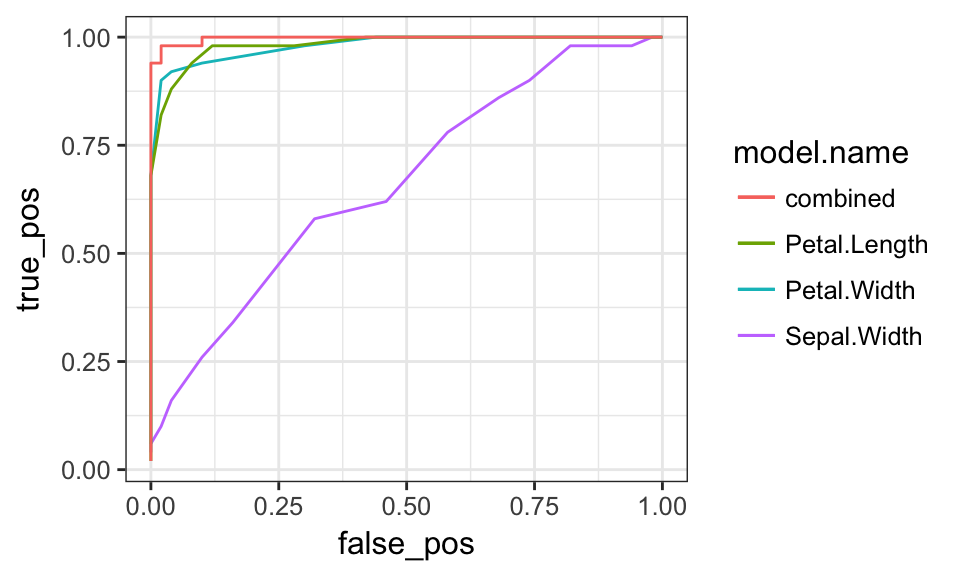

```r
ROC4 <- calc_ROC(probabilities=glm.out$fitted.values,
                 known_truth=iris.small$Species,
                 model.name="combined")

ggplot(data=NULL, aes(x=false_pos, y=true_pos)) +
  geom_line(data=ROC1, aes(color=model.name)) +
  geom_line(data=ROC2, aes(color=model.name)) +
  geom_line(data=ROC3, aes(color=model.name)) +
  geom_line(data=ROC4, aes(color=model.name))
```

# 3. If this was easy

Calculate the area under the ROC curve (AUC) for your first model (stored previously in the variable `ROC1`). (Hint: the function `lag()` makes this calculation very easy.)

```r
ROC1 %>% mutate(delta=false_pos-lag(false_pos)) %>%
  summarize(AUC=sum(delta*true_pos, na.rm=T))
```

```
##      AUC
## 1 0.7104
```

Now combine all ROCs from before into one big table, calculate the AUC for all of them, and arrange in descending order. Hint: you can combine separate data frames with the function `rbind()`. (The `r` in `rbind` stands for rows and indicates that we want to combine data frames by rows.)

```r
# combine all ROCs into one big table
ROCs <- rbind(ROC1, ROC2, ROC3, ROC4)

# calculate AUCs
ROCs %>% group_by(model.name) %>%
  mutate(delta=false_pos-lag(false_pos)) %>%
  summarize(AUC=sum(delta*true_pos, na.rm=T)) %>%
  arrange(desc(AUC))
```

```
## # A tibble: 4 × 2
##     model.name    AUC
##         <fctr>  <dbl>
## 1     combined 0.9972
## 2  Petal.Width 0.9888
## 3 Petal.Length 0.9876
## 4  Sepal.Width 0.7104
```